# Exploration of Political Campaign Contributions

# 2016 Presidential Election for Pennsylvania

### July 2017

This investigation explores campaign contributions made to United States Presidential Candidates in the 2016 election cycle in the state of Pennsylvania, whose contest was decided by less than one percentage point.

The data set can be found on the Federal Election Commisson page at http://classic.fec.gov/disclosurep/pnational.do. Select the 2016 radio button near the top of the page. Go to right sidebar and click “Export Contributor Data” button. Download PA.zip and uncompress on your PC.

The data set contains records of individual contributions made by Pennsylvanians to political candidates for President of the United States during the 2016 Presidential Campaign. The list includes donations (and a few refunds) made during both the primary and general election seasons which spanned from early 2015 until the November 2016 general election.

Each row represents one donation made by one person to one presidential candidate. Each row includes information about the candidate, including the Committee Id, Candidate Id, and Candidate Name. Each row also includes contributor (donor) information such as the Name, City, State, Zip Code, Employer, and Occupation. The donations in dollars and cents are indicated in the receipt column. There is also memo, form, transaction, and election indication information per row.

# Univariate Plots Section

### Candidate Donation Counts

I started by taking a look at the first three columns of the data set, which represent Committee Id, Candidate Id, and Candidate Name. I checked to be sure the information was consistent across all three columns. For example, I wanted to assure we never saw candidate A’s Id in the same row as candidate B’s name. There were 24 candidates who received donations from Pennsylvania.

I looked at the whole data set and see 243513 rows, each which represent one donation made to a presidential candidate. I checked the contribution amounts and checked to see how many rows represent donations (positive receipts) and how many were refunds. Nearly 99% of the donation lines represent donations so this report will analyze donations further.

The listings and plots below show that Democrats Hillary Clinton and Bernie Sanders had the most donations, followed by Donald Trump in third place. Hillary Clinton received nearly half of the total number of donations from Pennsylvanians while Bernie Sanders netted nearly 25 percent so the two leading Democratic candidates netted over 70 percent of all donations in Pennsylvania. Among the Republicans, Donald Trump had the most donations with Ted Cruz getting just above half of Trump’s number. Republicans Benjamin Carson, Marco Rubio, and Rand Paul are in 5th to 7th place, each receiving over 1000 donations. These donation counts represent the total number of donations from early 2015 through the November 2016 election.

```
## [1] "Unique Candidate Count: "
```

```
## [1] 24
```

```
## # A tibble: 24 x 3
## # Groups:   Committee Id, Candidate Id [24]
##    `Committee Id` `Candidate Id`          `Candidate Name`
##             <chr>         <fctr>                    <fctr>
##  1      C00458844      P60006723              Rubio, Marco
##  2      C00500587      P20003281    Perry, James R. (Rick)
##  3      C00573519      P60005915       Carson, Benjamin S.
##  4      C00574624      P60006111 Cruz, Rafael Edward 'Ted'
##  5      C00575449      P40003576                Paul, Rand
##  6      C00575795      P00003392   Clinton, Hillary Rodham
##  7      C00577130      P60007168          Sanders, Bernard
##  8      C00577312      P60007242            Fiorina, Carly
##  9      C00577981      P80003478            Huckabee, Mike
## 10      C00578245      P60007572         Pataki, George E.
## # ... with 14 more rows
```

```
## [1] "Total Donation Lines Count: "
```

```
## [1] 243513
```

```
## [1] "Total Donation / Refund Counts: "
```

```
## [1] 240788
```

```
## [1] 2725
```

```
## # A tibble: 24 x 4
##             `Candidate Name` `Political Party` `Donation Count` `Refund Count`
##                       <fctr>             <chr>            <dbl>          <dbl>
##  1   Clinton, Hillary Rodham        Democratic           118218           1003
##  2          Sanders, Bernard        Democratic            59249            372
##  3          Trump, Donald J.        Republican            29884            770
##  4 Cruz, Rafael Edward 'Ted'        Republican            15313            230
##  5       Carson, Benjamin S.        Republican             9708             91
##  6              Rubio, Marco        Republican             2902            163
##  7                Paul, Rand        Republican             1189              3
##  8           Kasich, John R.        Republican              999             20
##  9            Fiorina, Carly        Republican              947             18
## 10                 Bush, Jeb        Republican              527             18
## # ... with 14 more rows
```

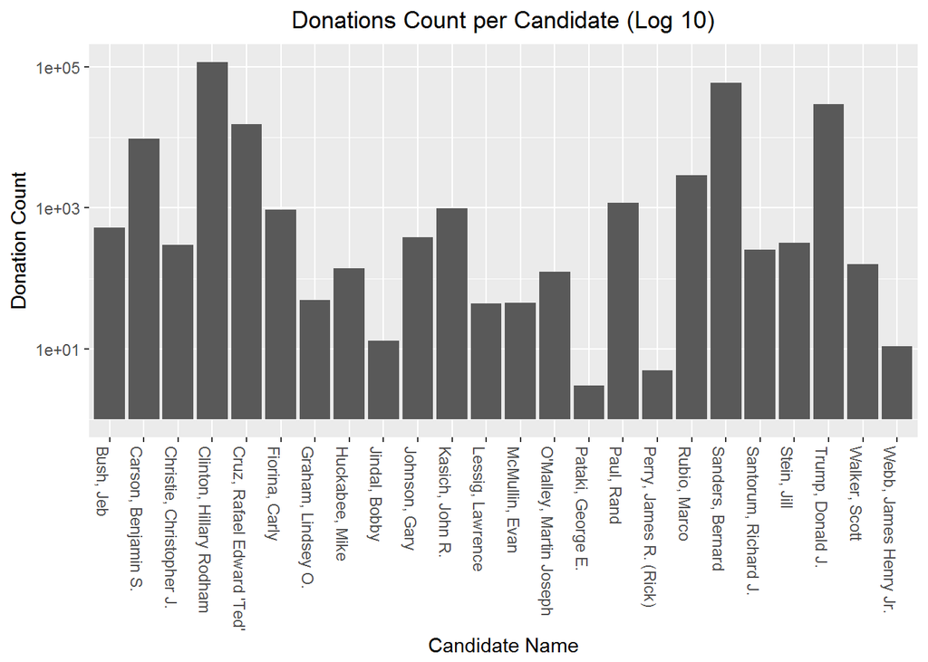

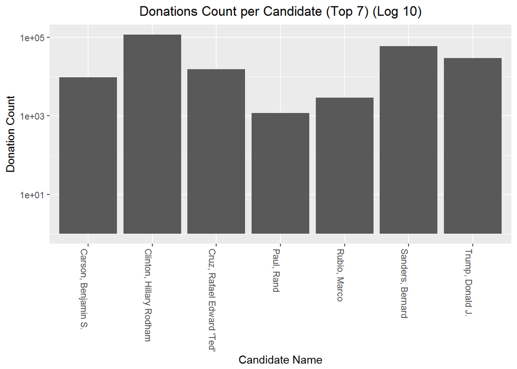

### Political Party Donation Counts

I then organized the same data by political party so that we can see the number of candidates and total number of donations by party. Note that we see 16 out of 17 declared Republican candidates since Jim Gilmore, former Virginia Governor, did not get any donations in Pennsylvania.

There were way more Republican candidates in the 2016 Presidential Primaries compared to the Democrats (16-5) but the Democrats gathered close to three times as many donations as the Republicans for the full 2016 campaign cycle.

```
## # A tibble: 5 x 3
##   `Political Party` `Candidate Count` `Donation Count`
##               <chr>             <int>            <dbl>
## 1        Democratic                 5           177647
## 2        Republican                16            62388
## 3       Libertarian                 1              385
## 4             Green                 1              323
## 5       Independent                 1               45
```

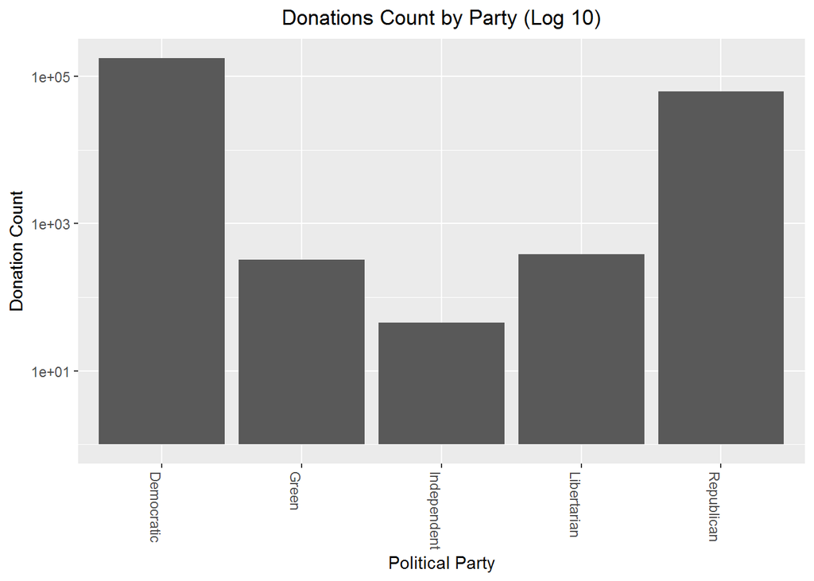

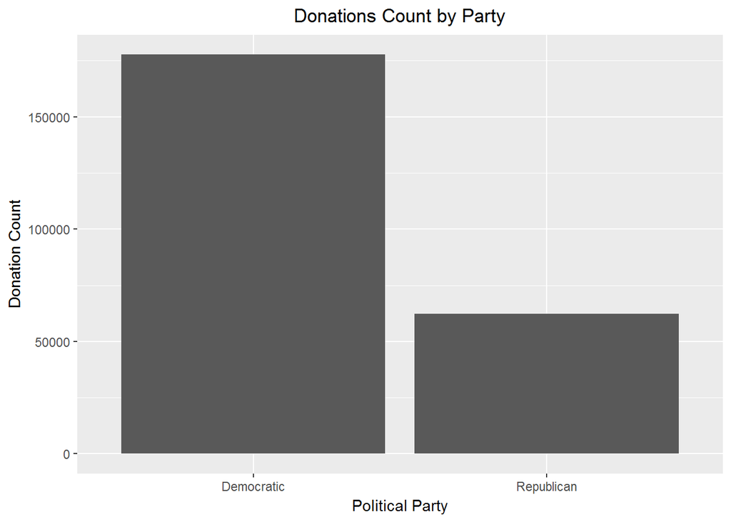

### Individual Donation Amounts

We now know the number of donations and the total contributions made to political candidates and parties in Pennsylvania in the 2016 election cycle. Here, the investigation looks at the amounts of individual donations.

The summary data tells us that the bulk of individual donations amounts are small, with over 75% of them under $80. The mean is higher than the 75th percentile thanks to a few large donations, some as high as $10800!

```
##     Min.  1st Qu.   Median     Mean  3rd Qu.     Max.
##     0.05    15.00    28.00   109.00    80.00 10800.00
```

The first plot below shows donations amounts up to $800 on the x-axis. Even with that adjustment, the data is long-tailed. Most of the donations amounts are below $100. About 75000 donation amounts are up to $20 and about 45000 donations are between $20 and $40. There are around 25000 donations near $100. The second plot below adjusts the x-scale logaritmically. This plot shows over 20000 donations each near $10, $25, $50, and $100.

When I take the counts of individual donation amounts, the table tells us the most frequent donation amounts. There were over 35000 $25.00 donations, 28000 $50.00 donations, 24000 $100.00 donations, and over 20000 $10.00 donations. There were 8000 donations at $250.00! Incredibly, over 9000 donations were exactly $27.00!

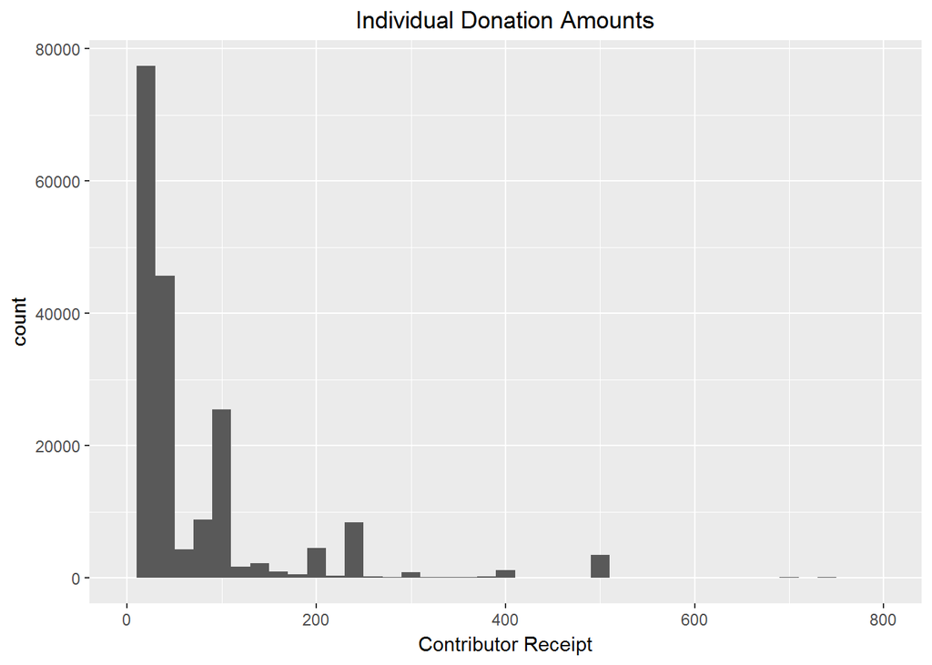

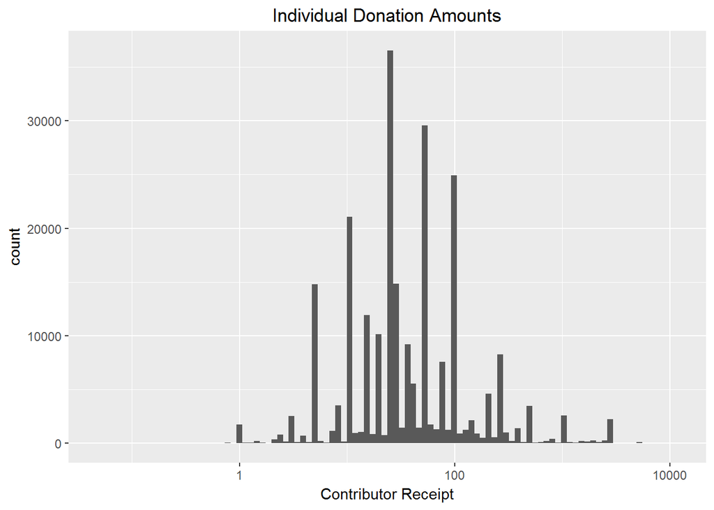

```
## # A tibble: 10 x 2
##    `Contributor Receipt` Count
##                    <dbl> <int>
##  1                    25 35432
##  2                    50 28006
##  3                   100 24187
##  4                    10 20635
##  5                     5 14754
##  6                    15 10425
##  7                    27  9158
##  8                   250  8013
##  9                    20  5296
## 10                    40  4922
```

### Donor Characteristics

At this point, the report looks at the donors. There are 56383 unique donors, 2029 unique cities, 1598 unique zip codes, and 8446 unique occupations. For the occupations, this lists the job titles listed by the donors and may include variants of the same occupation (such as “Software Developer” and “Software Engineer”) listed as sepearate occupations. I combined a few very common occupations during the data cleaning process.

```
## [1] "Number of unique donors:"
```

```
## [1] 56383
```

```
## [1] "Number of unique donor cities:"
```

```
## [1] 2029
```

```
## [1] "Number of unique donor zip codes:"
```

```
## [1] 1598
```

```
## [1] "Number of unique donor occupations:"
```

```
## [1] 8446
```

### Donor Cities

The most common two donor cities are Philadelphia and Pittsburgh, the most populous cities in Pennsylvania - with over 54000 donations between them (about 22.5% of the total number of donations). Harrisburg, the state capital, comes in a distant third. West Chester, in fourth place, is about 35 miles west of Philadelphia. Among the top ten cities, eight of them are in the eastern half of the state (Pittsburgh and State College are not). Harrisburg, Lancaster, and York are all in south central Pennsylvania. Allentown, Belthlehem, and Reading are all in east central Pennsylvania.

Among the 11th to 20th most common cities, seven are in the Philadelphia suburbs (Yardley, Doylestown, Media, Wayne, Newtown, Bryn Mawr, and Wynnewood).

The plot shows donation counts from the top 20 cities. The y-scale is logarithmic.

```
## # A tibble: 20 x 2
##    `Contributor City` Count
##                <fctr> <int>
##  1       PHILADELPHIA 32597
##  2         PITTSBURGH 21516
##  3         HARRISBURG  3612
##  4       WEST CHESTER  3601
##  5          LANCASTER  3547
##  6      STATE COLLEGE  2974
##  7               YORK  2843
##  8          BETHLEHEM  2576
##  9          ALLENTOWN  2100
## 10            READING  1990
## 11               ERIE  1954
## 12            YARDLEY  1869
## 13         DOYLESTOWN  1841
## 14              MEDIA  1768
## 15      MECHANICSBURG  1718
## 16              WAYNE  1683
## 17            NEWTOWN  1554
## 18          BRYN MAWR  1522
## 19          WYNNEWOOD  1460
## 20           CARLISLE  1359
```

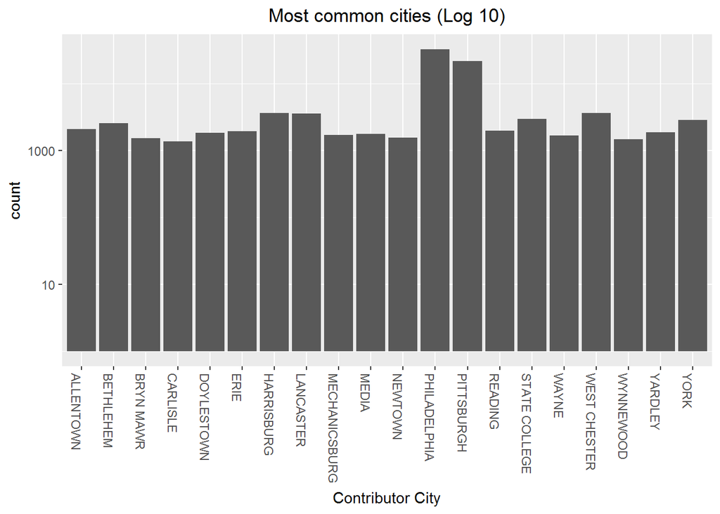

### Donor Zip Codes

The zip codes were grouped by its first three digits. The first three digits tells us which parts of Pennsylvania had the most donors during the 2016 presidential campaign. A map of Pennsylvania zip codes grouped this way is available [here](http://amedcoedu.com/maps/PA0.gif).

Above, we saw that many of the common donor cities were near Philadelphia. Philadelphia and its closest suburbs are in the 190 and 191 zip code groups. There were just over 70000 donations made from these two groups - nearly 30% of the total number of donations for the state. The Pittsburgh area (152) added another 22270 donations. The next three zip code groupings (193,194,and 189) represent parts of Chester, Montgomery, and Bucks Counties, which are in the Philadelphia suburbs. Harrisburg (170) and Allentown (180) are also in the top ten.

The top ten zip codes are plotted in a histogram below. The y-axis depicts donation count and is not transformed.

```
## # A tibble: 10 x 2
##    `Contributor Zip` Count
##                <chr> <int>
##  1               190 36723
##  2               191 33398
##  3               152 22270
##  4               193 13460
##  5               194 12559
##  6               189 11346
##  7               170 10855
##  8               180  9413
##  9               151  6574
## 10               150  5510
```

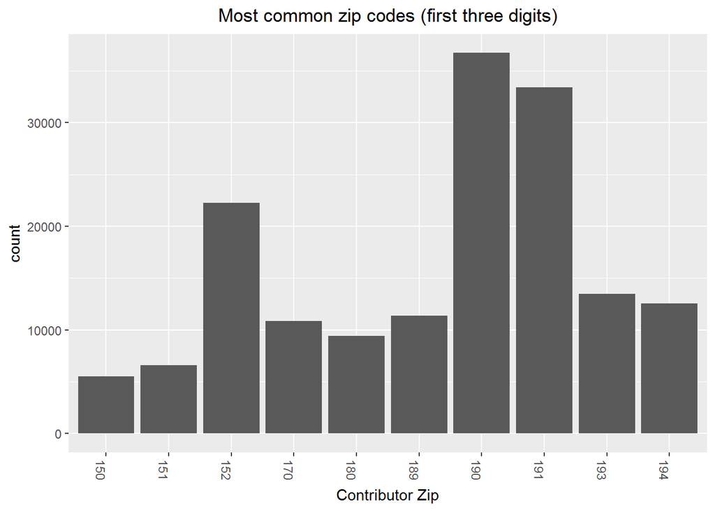

### Donor Occupations

Out of the 240788 donations, 55524 of them came from retired people - 23 percent! In a surprise, unemployed people made the second highest number of donations with over 17000 donors not employed. The “Information Requested” category was third in the original data set.

If we exclude “Information Requested”, Attorneys have the third highest donation count at 7639. Professors, Physicians, and Teachers each have over 5000 donations. There are 17 occupations each having at least 1000 donations to a candidate during the 2016 campaign.

The plot shows counts of the top 20 occupations and is transformed using log10 function. “Information Requested” and “Information Requested Per Best Efforts” is not shown in the plot. Executive and Artist, which were in 21st and 22nd place, show up in the plot.

```
## # A tibble: 20 x 2
##                  `Contributor Occupation` Count
##                                    <fctr> <int>
##  1                                RETIRED 55524
##  2                           NOT EMPLOYED 17387
##  3                  INFORMATION REQUESTED 10235
##  4                               ATTORNEY  7639
##  5                              PROFESSOR  5810
##  6                              PHYSICIAN  5723
##  7                                TEACHER  5372
##  8                              HOMEMAKER  3937
##  9                                  NURSE  3454
## 10                             CONSULTANT  2730
## 11                                MANAGER  1872
## 12                                  SALES  1843
## 13                               ENGINEER  1776
## 14                                  OWNER  1744
## 15 INFORMATION REQUESTED PER BEST EFFORTS  1527
## 16                          SELF EMPLOYED  1527
## 17                                STUDENT  1391
## 18                      SOFTWARE ENGINEER  1223
## 19                           PSYCHOLOGIST  1063
## 20                              PRESIDENT   967
```

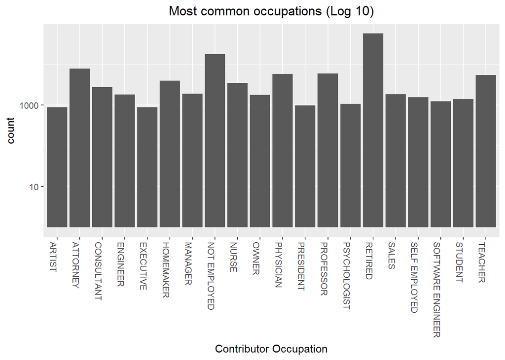

# Univariate Analysis

### What is the structure of your dataset?

The data set for Pennsylvania Campaign Contributions for the 2016 Presidential Election contains 18 columns. The first three columns identifies the Presidential Candidate using Committee Id, Candidate Id, and Candidate Name. The next six columns Ids each contributor by Name, City, State, Zip, Employer, and Occupation.

The donation is identified by the next three columns - Receipt (Amount in dollars and cents), Receipt Date, and Receipt Description. The last six columns are used by the campaigns; these are Memo Code, Memo Text, Form Type, File Number, Transaction Type Id, and Election Type Indicator (such as Primary, General, and Other).

### What is/are the main feature(s) of interest in your dataset?

I initially examined the number of donations vs. refunds where donation amounts have positive receipt amounts while refunds have negative receipt amounts. I dove deeper into donations since they make up 99% of the data set.

I also looked at donation counts for individual candidates and their respective political parties.

The number of unique donors and the most common donation amounts are also a main feature of the data set.

### What other features in the dataset do you think will help support your investigation into your feature(s) of interest?

My investigation will be helped by looking at the donor’s location (city - zip), occupation, and donation dates. Donations are broken into these categories later in the investigation.

### Did you create any new variables from existing variables in the dataset?

I added the candidate’s political party to the data set so that I could examine the number and amount of donations by party. The parties are Democratic, Republican, Green, Libertarian, and Independent. Most of the rows contain data for either a Democratic or Republican candidate.

I also added a “Donation” column to one of my data subsets in order to help me count donations vs. refunds. Donations made up 99% of donation lines in the original data set.

### Of the features you investigated, were there any unusual distributions? Did you perform any operations on the data to tidy, adjust, or change the form of the data? If so, why did you do this?

I cleaned the data set to exclude donations lines with donations of $0.00, improper city formats, and improper zip code formats. In addition, I filled in the “Election Type Indciator” for empty entries based on the donation date compared to Pennsylvania’s primary date (April 26, 2016). I also combined the most common donor occupations (so all “Lawyers” are counted as “Attorneys” for example).

When I examined the donation data by zip code, I decided to group the zip codes by their first three digits. This helped me understand which parts of Pennsylvania contained the highest number of donors. The city of Philadelphia, the city of Pittsburgh, and the suburbs of Philadelphia provided most of the donations candidates received in Pennsylvania.

I performed a log10 x-scale transformation while plotting the individual donation amounts because that data was long-tailed. This plot helped me see which small donation amounts were the most common. I also performed a log10 y-scale on plots containing small counts. These plots are for donation counts by candidate, donation counts by political party (including all parties), common donor cities, and common donor occupations.

I was surprised to see over 17000 unemployed people make donations to a presidential campaign - in second place among all occupations!

In addition, the candidate who lost Pennsylvania and the general election received four times as many donations as the winning candidate!

# Bivariate Plots Section

### Candidate Donation Sums

The Bivariate part of the investigation begins by examining the total amount of donations raised by the candidates.

Democratic candidate Hillary Clinton raised the greatest sum of money at nearly $13 million - nearly half of the total sum raised for Pennsylvania! Republican Donald Trump raised the second highest sum despite having the third highest number of donations. However, Trump raised only one third as much money as Clinton did in Pennsylvania. Democrat Bernie Sanders had the third highest total money raised with the second highest number of donors.

Republican Ted Cruz raised the fourth highest amount of money and had the fourth highest number of donors. Marco Rubio sneaked into fifth place for money raised in Pennsylvania despite having only 30 percent as many individual donations as sixth place finisher Ben Carson.

```
## [1] "Total Donation Sum: "
```

```
## [1] "26,245,104"
```

```
## # A tibble: 24 x 4
##             `Candidate Name` `Political Party` `Donation Count` `Donation Sum`
##                       <fctr>             <chr>            <dbl>          <dbl>
##  1   Clinton, Hillary Rodham        Democratic           118218     12987486.0
##  2          Trump, Donald J.        Republican            29884      4261938.9
##  3          Sanders, Bernard        Democratic            59249      2525635.7
##  4 Cruz, Rafael Edward 'Ted'        Republican            15313      1547920.2
##  5              Rubio, Marco        Republican             2902      1205312.8
##  6       Carson, Benjamin S.        Republican             9708       921625.4
##  7           Kasich, John R.        Republican              999       644423.1
##  8                 Bush, Jeb        Republican              527       479538.0
##  9  Christie, Christopher J.        Republican              298       436091.0
## 10            Fiorina, Carly        Republican              947       353288.3
## # ... with 14 more rows
```

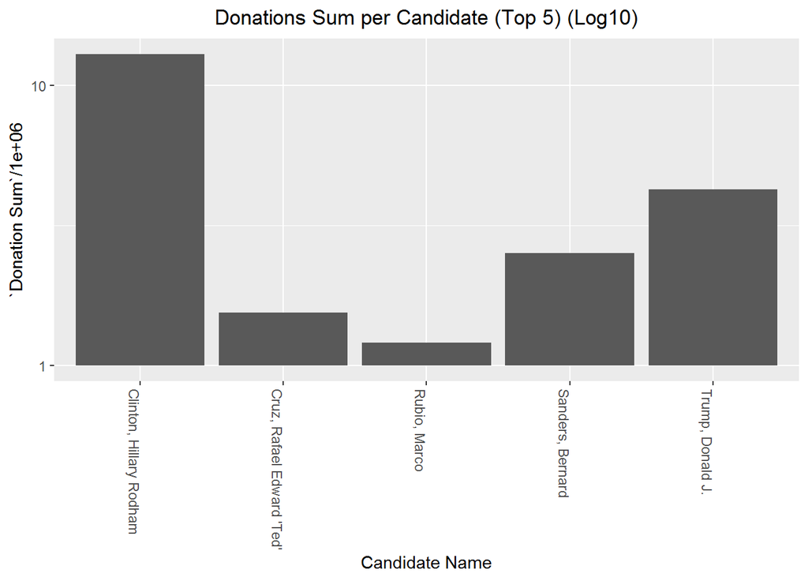

### Political Party Donation Sums

In this section, the donation sum data is organized by political party so that we can see the number of candidates and the amount of money raised by party. Once again, we see 16 out of 17 declared Republican candidates since Jim Gilmore failed to raise money in Pennsylvania.

The below list and plot shows that the Democratic candidates raised over $15.6 million dollars total comapred to the Republicans’ $10.45 million. Hillary Clinton and Bernie Sanders received almost all of the Democratic donations! Clinton herself received more donations from Pennsylvania ($12.9 million from above section) than all the Republican candidates put together!

```
## # A tibble: 5 x 3
##   `Political Party` `Candidate Count` `Donation Sum`
##               <chr>             <int>          <dbl>
## 1        Democratic                 5    15643688.13
## 2        Republican                16    10453803.55
## 3       Libertarian                 1       93072.61
## 4             Green                 1       51106.73
## 5       Independent                 1        3432.50
```

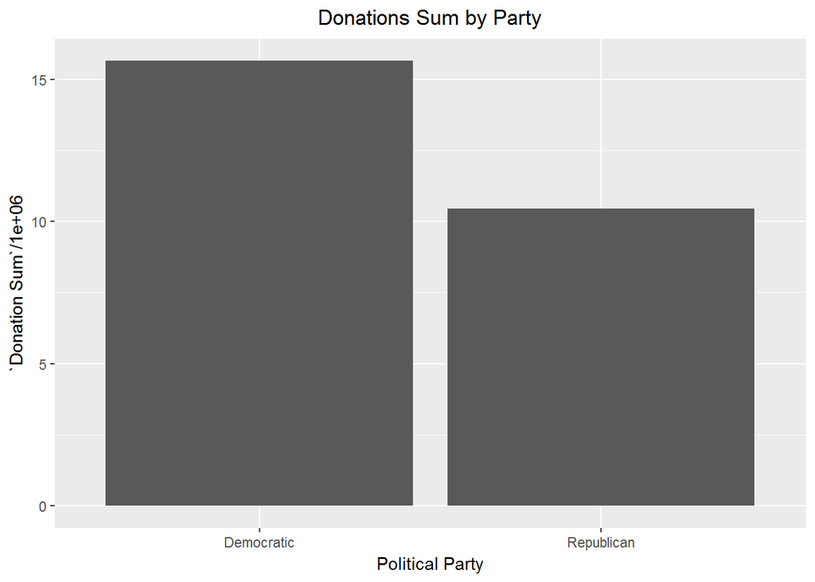

### Candidate Amount per Donation

In this section, I will investigate the amount of money per donations raised by the candidates and the major political parties. The table below shows little relationship between the amount per donation and how the candidate performed in Pennsylvania! Most of the highest scorers in this category, such as New Jersey Governor Chris Christie, were not even in the race by the time of Pennsylvania’s primary! Earlier primary contests in Iowa, New Hampshire, South Carolina, and Florida narrowed the contestants on the Republican side.

When we narrow the list to Pennsylvania primary contestants, Republican John R. Kasich raised the most money per donation ($645!) but he finished with only 20% of the Republican vote. He only had 999 donations, far less than anyone else in this list. Donald Trump raised $142.62 per donation and won the primary vote easily with over 56% of the vote. The lowest amount per donation was Bernie Sanders with only $42.63 per donation. Sanders finished behind Clinton in Pennsylvania by 12 points (56-44%).

The amount per donation (as well as total money raised) is not a good predictor of the winners of the primary and general election but may tell us about who is donating to each candidate.

```
## [1] "Candidate Amount per Donation:"
```

```
## # A tibble: 24 x 3
##             `Candidate Name` `Political Party` `Amount per Donation`
##                       <fctr>             <chr>                 <dbl>
##  1   Clinton, Hillary Rodham        Democratic             109.86048
##  2          Trump, Donald J.        Republican             142.61608
##  3          Sanders, Bernard        Democratic              42.62748
##  4 Cruz, Rafael Edward 'Ted'        Republican             101.08537
##  5              Rubio, Marco        Republican             415.33865
##  6       Carson, Benjamin S.        Republican              94.93463
##  7           Kasich, John R.        Republican             645.06812
##  8                 Bush, Jeb        Republican             909.93928
##  9  Christie, Christopher J.        Republican            1463.39262
## 10            Fiorina, Carly        Republican             373.06048
## # ... with 14 more rows
```

```
## [1] "Candidate Amount per Donation (Primary contestants only):"
```

```
## # A tibble: 5 x 3
##            `Candidate Name` `Political Party` `Amount per Donation`
##                      <fctr>             <chr>                 <dbl>
## 1   Clinton, Hillary Rodham        Democratic             109.86048
## 2          Trump, Donald J.        Republican             142.61608
## 3          Sanders, Bernard        Democratic              42.62748
## 4 Cruz, Rafael Edward 'Ted'        Republican             101.08537
## 5           Kasich, John R.        Republican             645.06812
```

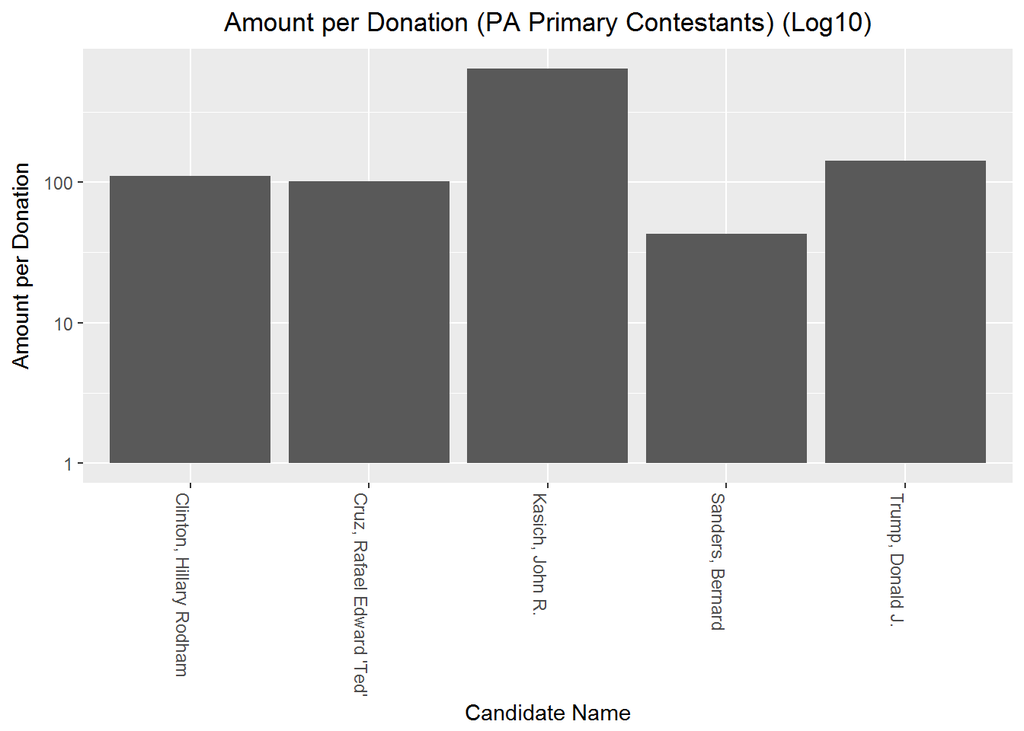

### Political Party Amount per Donation

When we analyze amount per donation by party, the Libertarians’ have the lead. Unfortunately for them, they only received 385 donations. Among the major parties, the Republican Party raised nearly twice as much per donation as the Democrats. The Democrats had nearly three times as many individual donations so they were able to raise 50% more money from Pennsylvanians as the Republicans.

```
## # A tibble: 5 x 3
##   `Political Party` `Candidate Count` `Amount per Donation`
##               <chr>             <int>                 <dbl>
## 1        Democratic                 5              88.06053
## 2        Republican                16             167.56113
## 3       Libertarian                 1             241.74704
## 4             Green                 1             158.22517
## 5       Independent                 1              76.27778
```

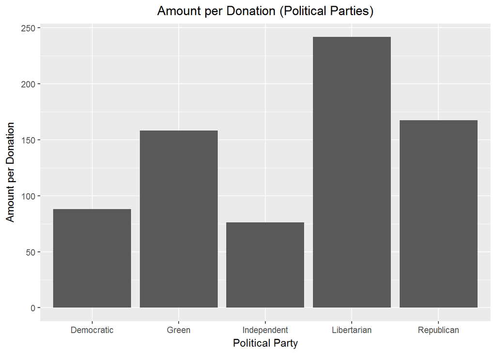

### Individual Donation Amounts per Candidate

Recall from the Univarite plots we saw the average donation amount was $109.00, which is higher than the 3rd Quartile amount of $80.00! In this section we will break down the individual donation amounts for both primary contestants and political parties.

The second plot excludes Kasich, allowing us to take a close look at the other four candidates who competed in the primaries. Two of the four candidates have an average donation above their 75th percent value; they are Hillary Clinton ($90 versus $110), and Donald Trump ($105 versus $143). Ted Cruz donors’ have their 75th percentile and average around $100. Bernie Sanders has similar 75th percentile and average values near $45 per donation.

The median donation amounts for the candidates are near the following values: Kasich = $250, Cruz = $50, Trump = $50, Sanders = $25, and Clinton = $25.

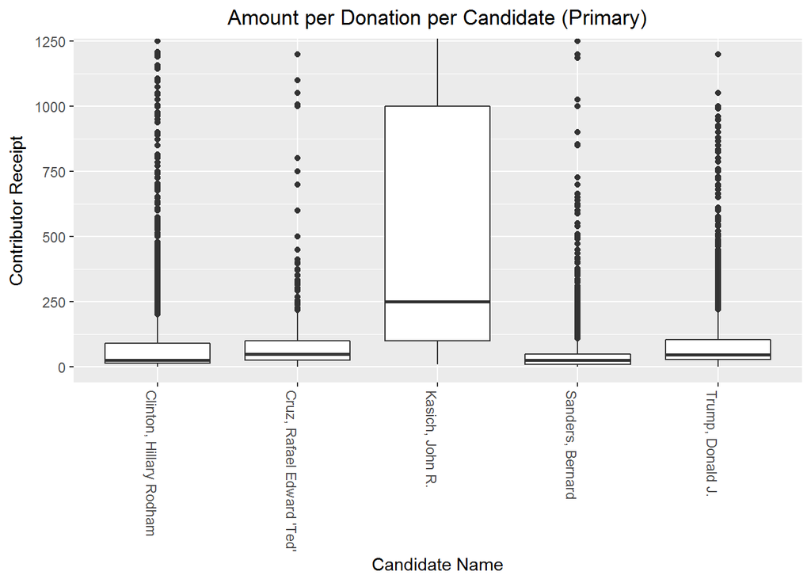

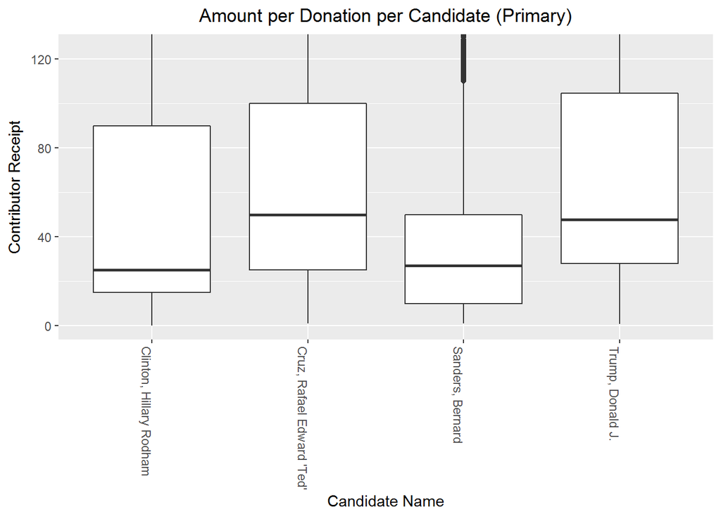

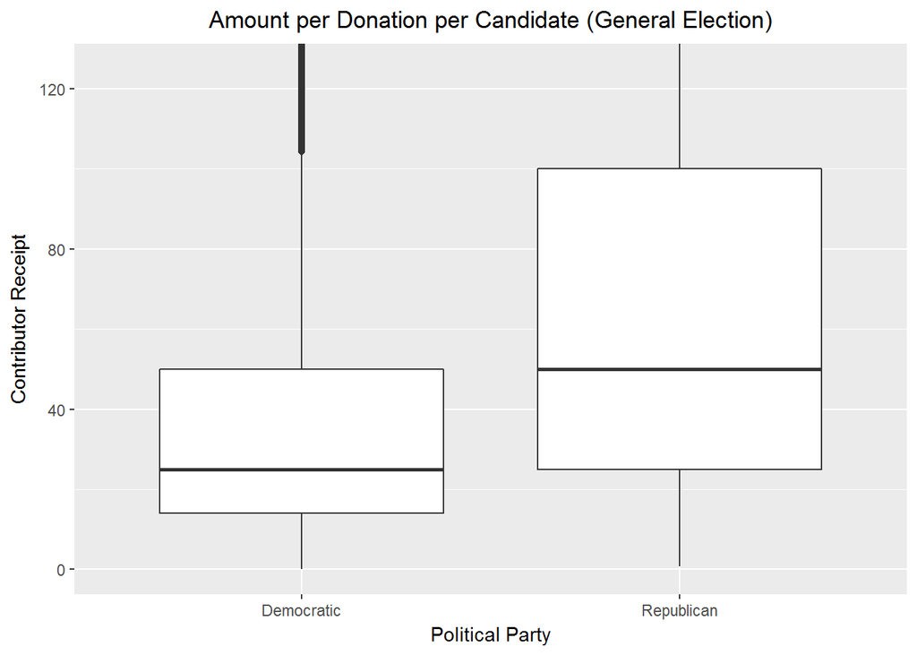

### Donations by Season

This part of the report investigates donations by seasons for candidates where the “season” refers to either the 2016 primaries or general election season. The primary season is denoted by “P2016” and the general election season is denoted by “G2016”. The first plot below does not surprise based on the univariate analysis. When grouped by election type indicator and candidate name, Hillary Clinton lands the top two positions. She raised $7 million during the general election thanks to nearly 77000 donors. Mrs. Clinton raised close to $6 million during the primary season, getting donations from 41527 donors.

```
## # A tibble: 40 x 5
##    Season          `Candidate Name` `Political Party` `Donation Count` `Donation Sum`
##     <chr>                    <fctr>             <chr>            <int>          <dbl>
##  1  G2016   Clinton, Hillary Rodham        Democratic            76691      7036664.6
##  2  P2016   Clinton, Hillary Rodham        Democratic            41527      5950821.4
##  3  G2016          Trump, Donald J.        Republican            13688      2906628.4
##  4  P2016          Sanders, Bernard        Democratic            59249      2525635.7
##  5  P2016 Cruz, Rafael Edward 'Ted'        Republican            15246      1472701.6
##  6  P2016          Trump, Donald J.        Republican            16196      1355310.5
##  7  P2016              Rubio, Marco        Republican             2836      1077475.8
##  8  P2016       Carson, Benjamin S.        Republican             9662       902265.4
##  9  P2016           Kasich, John R.        Republican              981       613523.1
## 10  P2016                 Bush, Jeb        Republican              523       472638.0
## # ... with 30 more rows
```

If we break up the seasons by political party and plot, we can better visualize how much money candidates raised during the primaries and general election.

The Democratic primary plot shows Clinton’s nearly $6 million raised, more than double Bernie Sanders’s $2.5 million. The Republican sums were between $500K and $1.5 million for the top five finishers. John Kasich was a contestant in the primary despite getting less money from Pennsylvania Republicans than Marco Rubio and Ben Carson, who both dropped out of the race before the primary. The general election plot confirms that Clinton raised about 2.3 times as much money in Pennsylvania as Trump.

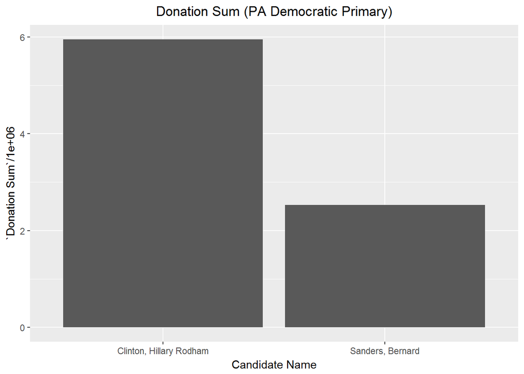

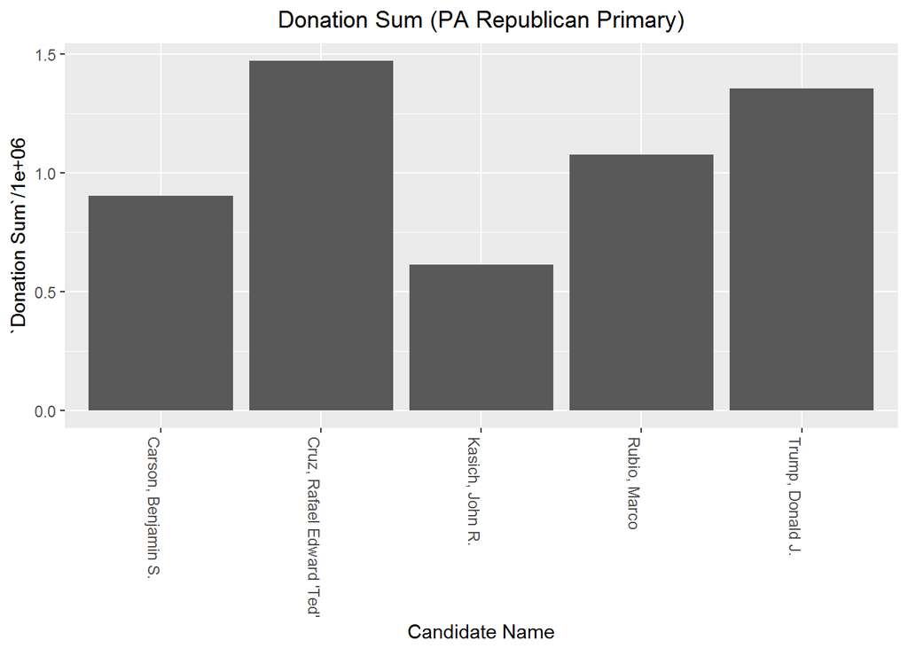

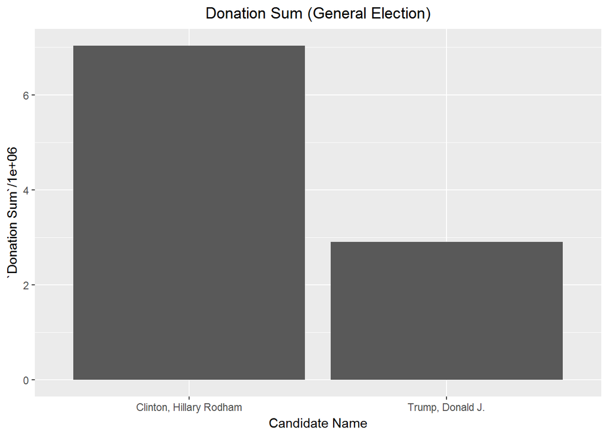

### Donations by City

Next, the investigation looks at donations by the contributors’ cities. The first list below shows that Hillary Clinton raised close to $2.8 million from heavily Democratic Philadelphia and over $1.5 million from Democratic Pittsburgh. That $4.35 million sum exceeds her Republican general election challenger’s total $4.26 million for the entire state of Pennsylvania! The Philadelphia suburbs provided Clinton even more of a fundraising boost as the suburban towns of Bryn Mawr, Wynnewood, Haverford, Newtown, West Chester, Wayne, Malvern, Gladwyne, Villanova, and Merion Station are in the top 20 and each donated $130K or more to Clinton. Philadelphia and its suburbs helps explain Clinton’s large donation sum and margin in Pennsylvania.

Those two cities also donated over $750K to Democrat Bernard Sanders. Republicans Donald Trump and Marco Rubio were able to get $262K and $126K from donors in Pittsburgh, making the top 20.

In the plot below, Clinton’s fundraising advantage in the most common donor cities becomes very apparent! The values plotted are the square root of the actual values. Trump’s bar *shows* only for Philadelphia, Pittsburgh, and West Chester and is only close to Clinton in West Chester.

```
## # A tibble: 20 x 3
##    `Contributor City`        `Candidate Name` `Donation Sum`
##                <fctr>                  <fctr>          <dbl>
##  1       PHILADELPHIA Clinton, Hillary Rodham      2780168.5
##  2         PITTSBURGH Clinton, Hillary Rodham      1571442.5
##  3       PHILADELPHIA        Sanders, Bernard       472239.7
##  4         PITTSBURGH        Sanders, Bernard       292846.3
##  5         PITTSBURGH        Trump, Donald J.       262306.7
##  6          BRYN MAWR Clinton, Hillary Rodham       233195.3
##  7          WYNNEWOOD Clinton, Hillary Rodham       225595.6
##  8           SCRANTON Clinton, Hillary Rodham       202618.4
##  9          HAVERFORD Clinton, Hillary Rodham       181408.6
## 10      STATE COLLEGE Clinton, Hillary Rodham       173364.2
## 11            NEWTOWN Clinton, Hillary Rodham       160340.5
## 12       WEST CHESTER Clinton, Hillary Rodham       148402.8
## 13              WAYNE Clinton, Hillary Rodham       147583.0
## 14          BETHLEHEM Clinton, Hillary Rodham       143219.4
## 15         HARRISBURG Clinton, Hillary Rodham       140487.3
## 16            MALVERN Clinton, Hillary Rodham       138346.9
## 17           GLADWYNE Clinton, Hillary Rodham       136468.8
## 18          VILLANOVA Clinton, Hillary Rodham       134966.8
## 19     MERION STATION Clinton, Hillary Rodham       131151.2
## 20         PITTSBURGH            Rubio, Marco       126457.0
```

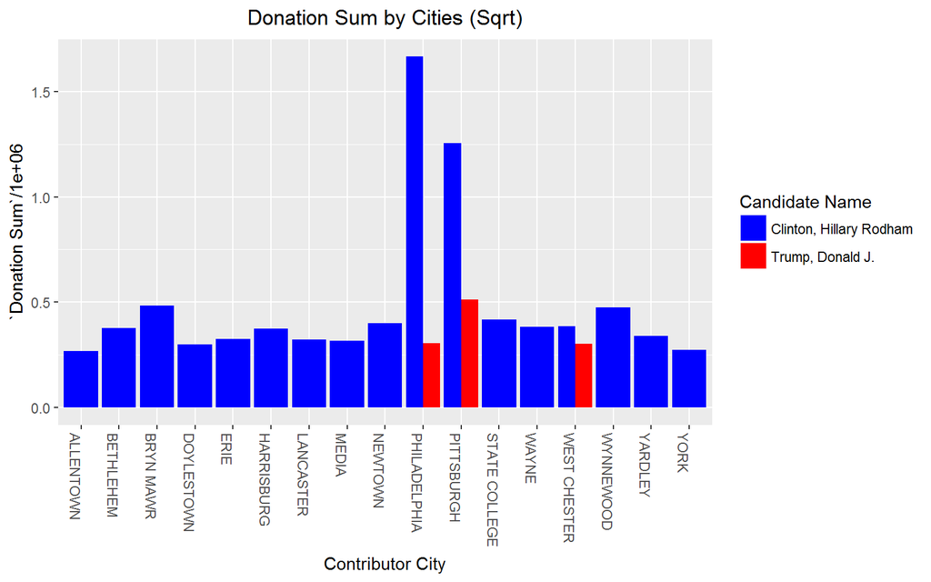

### Donations by Zip Code

We can see Clinton’s large advantage over Trump in the cities. Plotting by the first three digits of zip code may shed further light on the areas in which the general election candidates Hillary Clinton and Donald Trump raised the most money. The top 20 list by zip code grouping - shown below - again shows Clinton’s fundraising strength in the Philadelphia and Pittsburgh areas. Five of the top six zip code groupings (190,191,193,194,189) are in Philadelphia or its surrounding counties. Donald Trump received $513K from the “190” zip code grouping for 7th place.

The first plot shows how much more money Clinton raised in the Philadelphia area than Donald Trump. In Pittsburgh (152), Clinton received $1.6 million in donations compared to Trump’s $250K! In the Philadelphia suburbs (190), Clinton eclipsed Trump in donations by $2.9 million to $500K. Clinton’s margin in the city of Philadelphia (191) was even larger - $2.83 million to Trump’s $100K! These three zip code groupings alone gave Clinton a $7.33 million to $850K margin over Trump! This is the majority of Clinton’s total state margin in donations over Trump.

Scaling the y-axis as square root shows that Trump received more donations than Clinton in some rural parts of Pennsylvania. The zip code groupings of 153, 154, 157, 158, 159, and 167 - all in western Pennsylvania - gave Trump his best showing versus Clinton. The 153 and 154 areas - in the southwest corner of Pennsylvania - were solidly Democratic a generation ago. In the 1988 presidential election, Democrat Mike Dukakis nearly defeated Republican George H.W. Bush in Pennsylvania thanks to his victories in this part of the state (back then, the Philadelphia suburbs were Republican). Trump also broke even with Clinton in Berks County (195 and 196) near Reading, Pennsylvania, a traditionally Democratic area.

```
## # A tibble: 20 x 3
##    `Contributor Zip`        `Candidate Name` `Donation Sum`
##                <chr>                  <fctr>          <dbl>
##  1               190 Clinton, Hillary Rodham      2908848.7
##  2               191 Clinton, Hillary Rodham      2836273.9
##  3               152 Clinton, Hillary Rodham      1606250.1
##  4               193 Clinton, Hillary Rodham       689484.1
##  5               194 Clinton, Hillary Rodham       596213.6
##  6               189 Clinton, Hillary Rodham       566304.4
##  7               190        Trump, Donald J.       513404.3
##  8               191        Sanders, Bernard       476680.6
##  9               190        Sanders, Bernard       379327.7
## 10               180 Clinton, Hillary Rodham       320855.3
## 11               184 Clinton, Hillary Rodham       319557.3
## 12               170 Clinton, Hillary Rodham       305594.8
## 13               152        Sanders, Bernard       301767.8
## 14               190            Rubio, Marco       291393.8
## 15               193        Trump, Donald J.       275492.3
## 16               185 Clinton, Hillary Rodham       274127.6
## 17               152        Trump, Donald J.       273211.9
## 18               189        Trump, Donald J.       247811.0
## 19               170        Trump, Donald J.       235864.4
## 20               151 Clinton, Hillary Rodham       232881.1
```

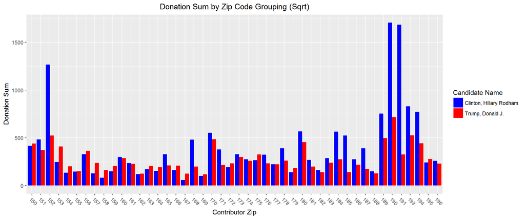

### Donations by Occupation

Let’s examine occupations to see which occupations formed the strength of both Clinton and Trump’s base of donation support. We can also see if any occupations drove up Clinton’s margin over Trump in donations.

```
## # A tibble: 20 x 3
##    `Contributor Occupation`        `Candidate Name` `Donation Sum`
##                      <fctr>                  <fctr>          <dbl>
##  1                  RETIRED Clinton, Hillary Rodham      2334215.1
##  2                 ATTORNEY Clinton, Hillary Rodham      1546884.6
##  3                  RETIRED        Trump, Donald J.      1076805.3
##  4    INFORMATION REQUESTED        Trump, Donald J.       713106.6
##  5    INFORMATION REQUESTED Clinton, Hillary Rodham       694576.6
##  6                PHYSICIAN Clinton, Hillary Rodham       479011.1
##  7                PROFESSOR Clinton, Hillary Rodham       420316.4
##  8                HOMEMAKER Clinton, Hillary Rodham       355272.2
##  9               CONSULTANT Clinton, Hillary Rodham       299169.1
## 10             NOT EMPLOYED Clinton, Hillary Rodham       188279.8
## 11                  TEACHER Clinton, Hillary Rodham       179171.4
## 12                PRESIDENT Clinton, Hillary Rodham       179089.5
## 13                    OWNER        Trump, Donald J.       178360.7
## 14                    OWNER Clinton, Hillary Rodham       174578.8
## 15                PRESIDENT        Trump, Donald J.       128337.1
## 16                  PARTNER Clinton, Hillary Rodham       127171.7
## 17                PHYSICIAN        Trump, Donald J.       120194.1
## 18                      CEO Clinton, Hillary Rodham       113963.6
## 19                  STUDENT Clinton, Hillary Rodham       104876.8
## 20            SELF EMPLOYED        Trump, Donald J.       103430.5
```

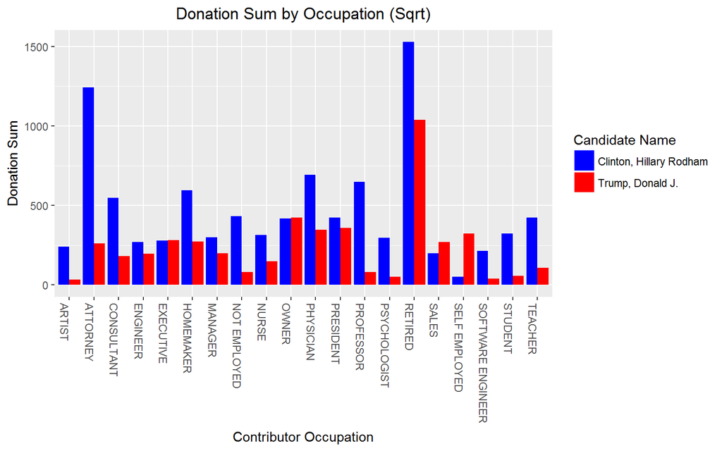

### Donations by Month

The final bivariate examination is donations over time. The contributor receipt dates are grouped by year-month (e.g., ‘2016/05’). The most competitive primary candidates are shown along with the general election candidates.

The first plot, with a normalized y-scale shows that Democratic front-runner Hillary Clinton received a boost in donations in the three months following her April 2015 announcement that she was running for President of the United States. She also raised more money from Pennsylvania than other candidates in December 2015 and January 2016. Some Pennsylvania Democrats were “Feeling the Bern” as Sanders took the monthly donations lead in February and March 2016. Clinton again led in each month from the April 2016 primary until the November general election in Pennsylvania campaign contributions.

A square root transformation of the y-axis better describes the donations on the Republican side. Most Pennsylvania Republicans did not believe Donald Trump had much of a shot at winning the party’s nomination in 2015 and spread their donations among other candidates including Carson, Cruz, Rubio, and Kasich. Ted Cruz enjoyed a three month boost in donations following his presidetial campaign announcement in March 2015. During the summer and fall of 2015, as Pennsylvania Republicans were evaluating candidates, Benjamin Carson and Marco Rubio started raising more money and Ted Cruz no longer led in monthly fundraising. By February 2016, John Kasich was also receiving donations along with the other Republicans not named Donald Trump. By March 2016, Carson and Rubio dropped out of the Republican race, resulting in lower donations. Cruz and Kasich saw their donations increase in March and April 2016 in advance of the Pennsylvania primary. After Donald Trump won the primary, and soon thereafter, the party nomination, did his monthly donations finally surge. Trump never raised the most money among Republicans during the primary season.

Finally, in June 2016, did Donald Trump finally receive $500K in monthly donations from Pennsylvania Republicans. Incredibly, Donald Trump won the state’s Republican primary by a wide margin despite the lack of donations compared against other Republicans. Trump then won Pennsylvania in the general election even though he received less donation money *every month* of the campaign then Clinton in the state!

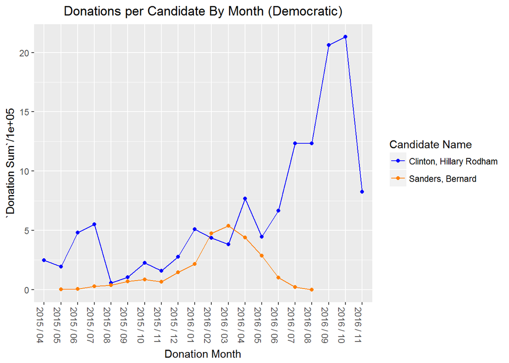

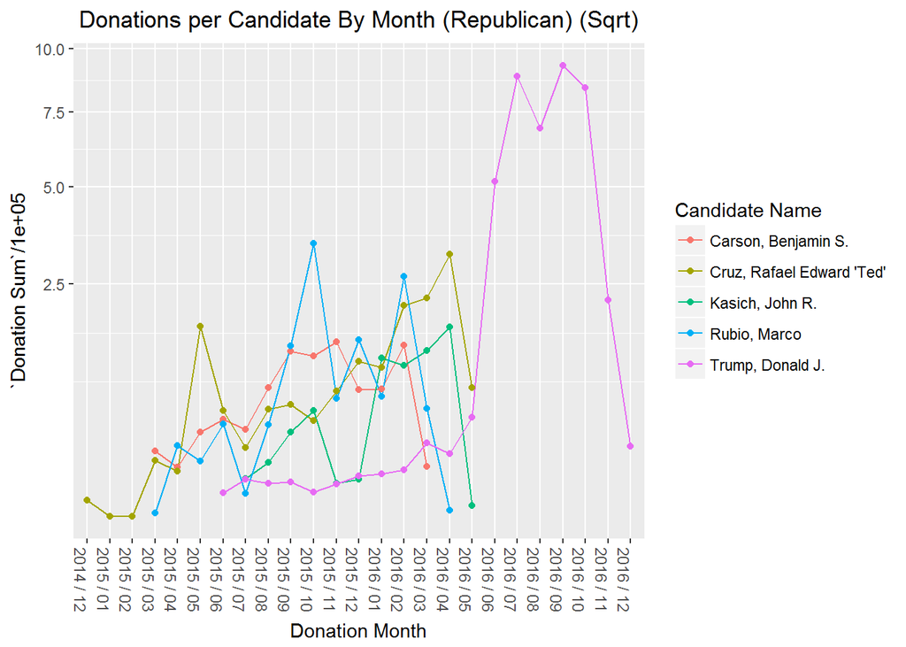

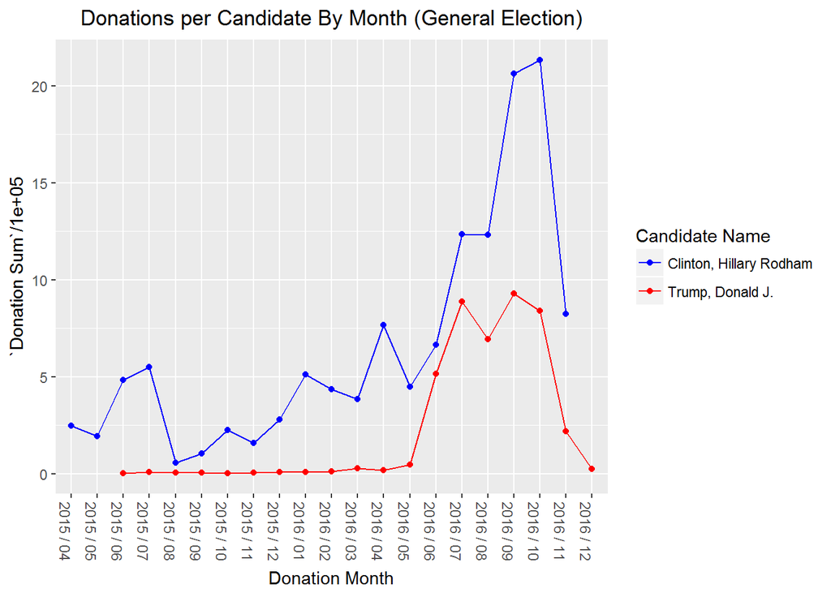

# Bivariate Analysis

### Talk about some of the relationships you observed in this part of the investigation. How did the feature(s) of interest vary with other features in the dataset?

The Republicans received a median of $50 per donation with an interquartile range of $25 to $100. The Democrats only received a median of $25 with an interquatile range of $15 to $50. The Democrats, however, had nearly three times as many donors as the Republicans in Pennsylvania, allowing the Democrats to raise 1.5 times as much money from donations. The mean individual donation amount for all candidates were skewed upwards by a few very large donations as all candidates had an average donations greater than or equal to their 75th percentile amount.

The largest drivers of campaign contributions in Pennsylvania during the 2016 campaign cycle was donor location and occupation.

The Philadelphia area and its suburbs donated heavily to Clinton. The “190” and “191” zip code groupings gave well over $5 million to the Clinton campaign, more than Donald Trump donations across the whole state of Pennsylvania. Clinton was able to pad her fundraising lead via the remaining Philadelphia suburbs and Pittsburgh.

Among the donors, those with the most common occupations, such as Attorneys, Physicians, Professors, and Homemakers, donated more money to Hillary Clinton than other candidates. Clinton also received twice the donation sum than Donald Trump from retired contributors.

Clinton also declared her candidacy before most other candidates, leading to a boost in donations during the Spring of 2015.

### Did you observe any interesting relationships between the other features (not the main feature(s) of interest)?

Donald Trump never received more monthly donations than other candidates during either the Republican primary nor in the general election.

However, Trump received more donations than Democrat Hillary Clinton from parts of Pennsylvania that has traditionally voted Democratic, including southwestern Pennsylvania and the Reading area. Reading is about 60 miles northwest of Philadelphia.

Amount per donation did not have any correlation with candidate success! Total donation sum only correlated with success in the Democratic primary.

### What was the strongest relationship you found?

The largest driver of Clinton’s high donation sums was the amount of money she raised from residents of Philadelphia and its suburbs. Clinton won Philadelphia and the suburban counties by a comfortable margin. Chester County (“193” zip code grouping), about 25-50 miles west of Philadelphia, was the only Pennsylvania county to vote for Republican Mitt Romney in 2012 and Democrat Hillary Clinton in 2016.

# Multivariate Plots Section

### Donations by Zip Code and Occupation (Clinton and Trump)

Based on the bivariate exploration, it could be useful to further examine the relationship among zip code groupings, donation month, and occupation. This part of the investigation may lead to further insight as to how Democrat Hillary Clinton received large amounts of campaign money and how Republican Donald Trump managed to win the state of Pennsylvania despite Clinton’s fundraising advantage.

When we look at zip code and occupation, the Top 20 listing and plot for Hillary Clinton’s donor contributions show that her largest group of contributors are Retirees and Attorneys in Philadelphia (190,191) and Pittsburgh (152) - all in the $200K to $500K range! Retirees and Attorneys in these three zip code regions together donated $2.25 million to the Clinton campaign! 12 of the top 15 items are from Philadelphia or its suburbs (189,190,191,193,194); the other three are from Pittsburgh!

In Donald Trump’s case, the list and plot shows his strongest donor group is retired donors across different areas of Pennsylvania; however, only one group has a donation sum above $100K.

Clinton donors’ most common occupations are Attorney, Consultant, Homemaker, Not Employed, Owner, Physician, President, Professors, Retired, and Teachers.

Trump donors’ most common occupations are Attorney, CEO, Executive, Homemaker, Owner, Physician, President, Retired, Sales, and Self Employed.

Clinton supporters across Pennsylvania, regardless of occupations, were more likely to make a donation in support of their candidate than Trump supporters.

```
## [1] "CLINTON ZIP/OCCUPATION TABLE: "
```

```
## # A tibble: 20 x 4
##      Zip Occupation `Donation Count` `Donation Sum`
##    <chr>     <fctr>            <int>          <dbl>
##  1   191   ATTORNEY             1550      501515.35
##  2   190    RETIRED             4573      446075.14
##  3   190   ATTORNEY             1382      419040.94
##  4   191    RETIRED             3659      395156.18
##  5   152    RETIRED             2704      253015.43
##  6   152   ATTORNEY              926      229417.17
##  7   193    RETIRED             2056      145116.43
##  8   190  PHYSICIAN              868      124717.68
##  9   194    RETIRED             1755      120747.42
## 10   189    RETIRED             1567      119132.46
## 11   152  PROFESSOR              562       99940.98
## 12   190  HOMEMAKER              426       95638.21
## 13   191  PROFESSOR              878       85428.50
## 14   191 CONSULTANT              481       85193.67
## 15   191  PHYSICIAN              854       83640.76
## 16   170    RETIRED             1261       79960.35
## 17   180    RETIRED              926       69874.03
## 18   190  PROFESSOR              670       69824.54
## 19   152  PHYSICIAN              452       66090.41
## 20   185   ATTORNEY               71       62557.55
```

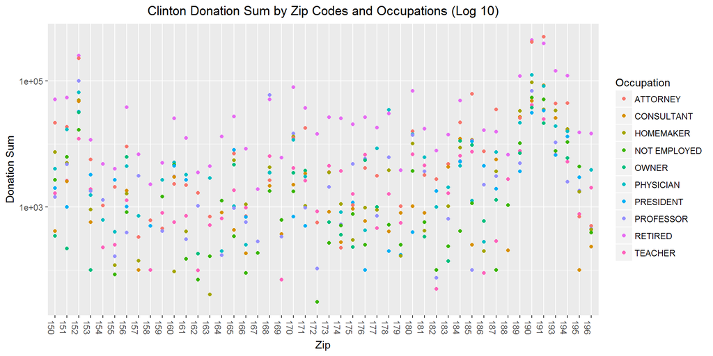

```
## [1] "TRUMP ZIP/OCCUPATION TABLE: "
```

```
## # A tibble: 20 x 4
##      Zip    Occupation `Donation Count` `Donation Sum`
##    <chr>        <fctr>            <int>          <dbl>
##  1   190       RETIRED              876      106001.16
##  2   193       RETIRED              579       91883.48
##  3   152       RETIRED              509       77321.25
##  4   170       RETIRED              785       75449.40
##  5   189       RETIRED              584       73580.85
##  6   180       RETIRED              571       61979.08
##  7   194       RETIRED              515       47557.11
##  8   175       RETIRED              325       34693.52
##  9   150       RETIRED              381       33454.38
## 10   153       RETIRED              173       32013.00
## 11   151       RETIRED              353       31215.25
## 12   190 SELF EMPLOYED               75       30008.07
## 13   173       RETIRED              352       26408.18
## 14   190         OWNER               51       25002.38
## 15   184       RETIRED              299       24006.11
## 16   191       RETIRED              270       23300.65
## 17   156       RETIRED              315       21686.04
## 18   153     PRESIDENT               11       18944.00
## 19   152     PRESIDENT               17       18632.20
## 20   170     PHYSICIAN               47       18265.00
```

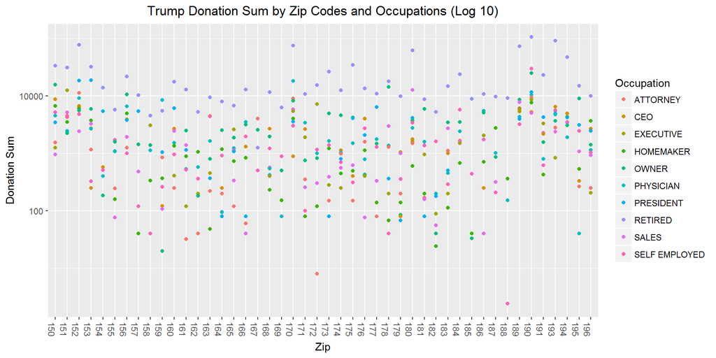

### Donations by Month and Occupation (Clinton and Trump)

When we look at donation month and occupation, we see that Democrat Hillary Clinton received donations from donors in each of the top occupations every month starting with Hillary Clinton’s declaration in April 2015. Clinton’s top donation months occurred from July through November 2016 when Retired Donors, Attorneys, Professors, and Physicians had donation months in the Top 20 list. Retired Democratic donors contributed a donation sum of over $400K in both September and October 2016, the last two months before the November 8 general election. Retired donors supplied over $200K in July and August 2016. Attorneys in Pennsylvania also provided Clinton with an early boost by donating about $100K in both June and July 2015, around the time Republican Donald Trump started his campaign for President.

Donald Trump did not receive donations from donors having some of his top occupations in 2015 and early 2016! For example, the Trump campaign only received donations from Retired, Physicians, and Self Employed donors in August 2015. Trump was seen as a long-shot at that time. It wasn’t until May 2016, when Donald Trump secured the Republican nomination, when he finally received donations from donors in each of his top ten occupations. Retired donors donated at least $150K to Trump’s campaign from June through October 2016.

Both candidates received more donations after wrapping up their party’s nomination until the general election.

```
## [1] "CLINTON MONTH/OCCUPATION TABLE: "
```

```
## # A tibble: 20 x 3
##    `Donation Month` Occupation `Donation Sum`
##               <chr>     <fctr>          <dbl>
##  1        2016 / 10    RETIRED      452306.09
##  2        2016 / 09    RETIRED      423819.05
##  3        2016 / 08    RETIRED      271029.44
##  4        2016 / 07    RETIRED      246350.87
##  5        2016 / 09   ATTORNEY      232026.54
##  6        2016 / 10   ATTORNEY      217817.79
##  7        2016 / 11    RETIRED      163639.24
##  8        2016 / 06    RETIRED      147389.73
##  9        2016 / 04    RETIRED      114207.02
## 10        2016 / 08   ATTORNEY      112074.33
## 11        2016 / 09  PROFESSOR      104050.01
## 12        2016 / 04   ATTORNEY      103065.29
## 13        2015 / 07   ATTORNEY      102360.00
## 14        2016 / 05    RETIRED      100284.61
## 15        2016 / 01   ATTORNEY      100145.53
## 16        2016 / 07   ATTORNEY       98917.76
## 17        2015 / 06   ATTORNEY       96017.89
## 18        2016 / 10  PHYSICIAN       90102.26
## 19        2016 / 03    RETIRED       87838.29
## 20        2016 / 11   ATTORNEY       87214.05
```

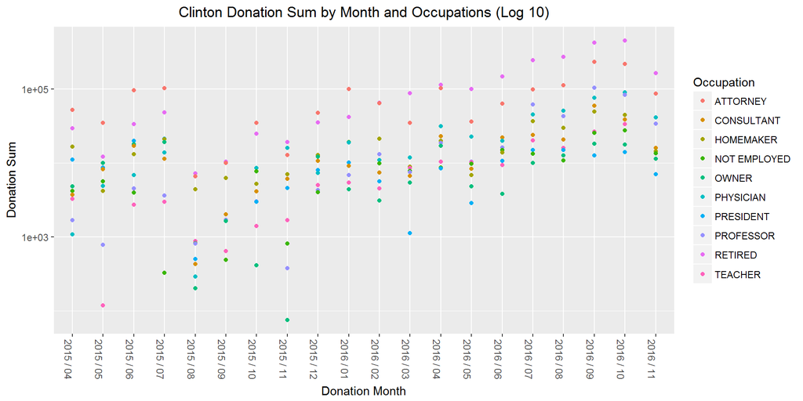

```
## [1] "TRUMP MONTH/OCCUPATION TABLE: "
```

```
## # A tibble: 20 x 3
##    `Donation Month`    Occupation `Donation Sum`
##               <chr>        <fctr>          <dbl>
##  1        2016 / 07       RETIRED      278827.15
##  2        2016 / 10       RETIRED      209012.21
##  3        2016 / 08       RETIRED      188521.33
##  4        2016 / 09       RETIRED      185275.21
##  5        2016 / 06       RETIRED      152193.62
##  6        2016 / 10         OWNER       48655.63
##  7        2016 / 09         OWNER       44863.78
##  8        2016 / 09     PRESIDENT       39225.00
##  9        2016 / 06     PRESIDENT       33647.88
## 10        2016 / 11       RETIRED       32766.76
## 11        2016 / 09     EXECUTIVE       31449.13
## 12        2016 / 07 SELF EMPLOYED       30800.93
## 13        2016 / 09     PHYSICIAN       27218.42
## 14        2016 / 06         OWNER       25111.07
## 15        2016 / 10     PRESIDENT       24565.29
## 16        2016 / 10     PHYSICIAN       24186.61
## 17        2016 / 09 SELF EMPLOYED       21956.39
## 18        2016 / 07     PHYSICIAN       20838.61
## 19        2016 / 09           CEO       20400.00
## 20        2016 / 08     PHYSICIAN       20332.87
```

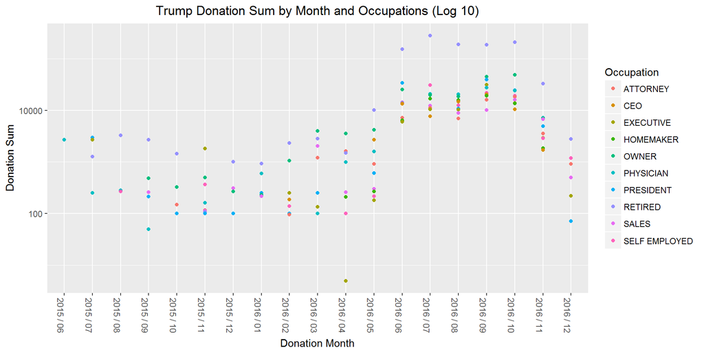

# Multivariate Analysis

### Talk about some of the relationships you observed in this part of the investigation. Were there features that strengthened each other in terms of looking at your feature(s) of interest?

The Multivariate Analysis confirms many of the findings of the Bivariate Analysis. Clinton’s strong fundraising in Pennsylvania was driven by Democratic donors in the Philadelphia area with the largest occupation groups being Retired and Attorneys. Retirees and Attorneys in Pittsburgh also drove Clinton’s donations sums upwards too. These *two* occupation groups in *three* zip code regions together donated $2.25 million to the Clinton campaign - about 1/6th of her total donation sum!

Trump’s low donation sums in the early stages of the primary cycle (in 2015) seems surprising at first. However, there were 17 Republican candidates running for the Republican nomination. Trump was also seen as a long-shot behind established politicians such as Florida Senator Marco Rubio, former Florida Governor Jeb Bush, and Ohio Governor John Kasich.

Trump also started his campaign two months after Clinton started hers. Clinton was heavily favored in the Democratic contest while Trump was in a crowded field. As a result, Clinton was able to build and maintain an advantage in fundraising compared to Trump.

### Were there any interesting or surprising interactions between features?

The first surprise was the amount of money Democrat Hillary Clinton was able to raise ($2.25 million) from only Retirees and Attorneys in Philadelphia and Pittsburgh!

The second surprise is that Republican Donald Trump still won Pennsylvania and the Presidential Election despite being outraised by Hillary Clinton *every month* of the campaign in Pennsylvania!

# Final Plots and Summary

### Plot One

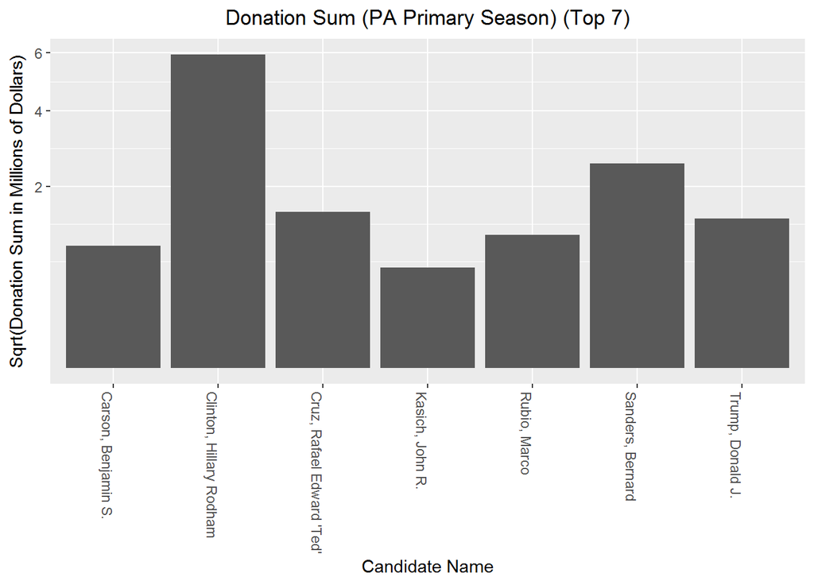

### Plot Two

```
## # A tibble: 60 x 4
## # Groups:   Occupation Category [?]
##    `Occupation Category` `Donation Month` num_donations sum_donations
##                    <chr>            <chr>         <int>         <dbl>
##  1              ATTORNEY        2015 / 04             1      51860.00
##  2              ATTORNEY        2015 / 05             1      34682.72
##  3              ATTORNEY        2015 / 06             1      96017.89
##  4              ATTORNEY        2015 / 07             1     102360.00
##  5              ATTORNEY        2015 / 08             1       6615.00
##  6              ATTORNEY        2015 / 09             1       9973.10
##  7              ATTORNEY        2015 / 10             1      35000.68
##  8              ATTORNEY        2015 / 11             1      12801.65
##  9              ATTORNEY        2015 / 12             1      47787.69
## 10              ATTORNEY        2016 / 01             1     100145.53
## # ... with 50 more rows
```

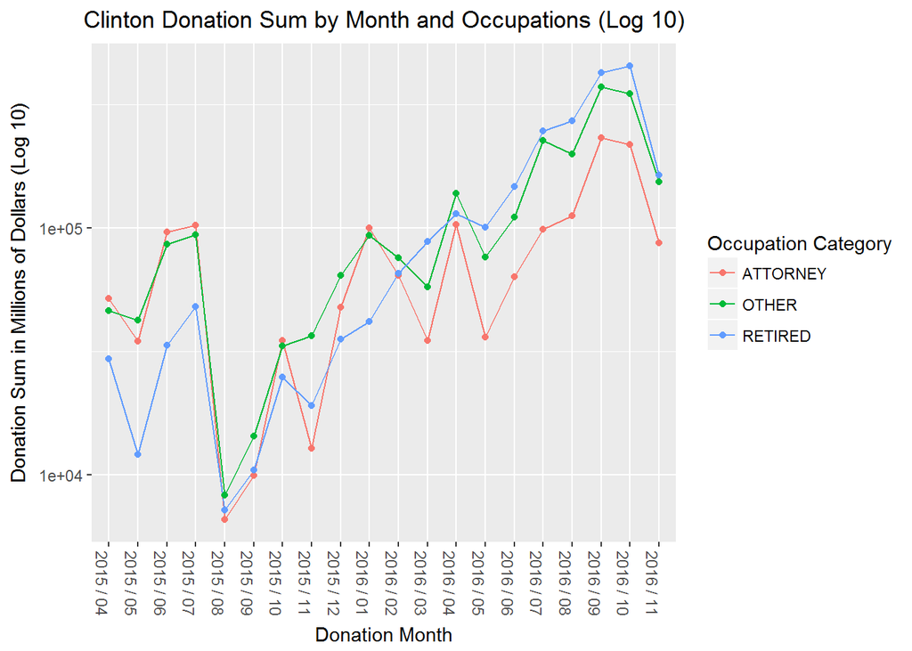

### Description Two

It’s clear that Democratic candidate Hillary Clinton raised more money than any other candidate in the primary and general election. The plot above shows which donors, grouped by occupation, drove Clinton’s donation sums upwards.

Hillary Clinton launched her presidential run in April 2015 and started receiving a large sum of donations right away! Pennsylvania Attorneys and Retired people funded the Clinton campaign more than any other occuption groups for every month of the campaign. The plot above shows Attorneys, Retired, and Other! “Other” includes all other declared occupations! In every month of the campaign from Clinton’s declaration to the general election, the three groups of Attorneys, Retirees, and Other donated nearly similar amounts of money to the campaign!

After the Democratic primary (April 26, 2016), all three of these occupation groups strongly funded Clinton. The logarithmic y-value is above 1000 for all occupation groups during this time period and above 10000 from July to October 2016!

### Plot Three

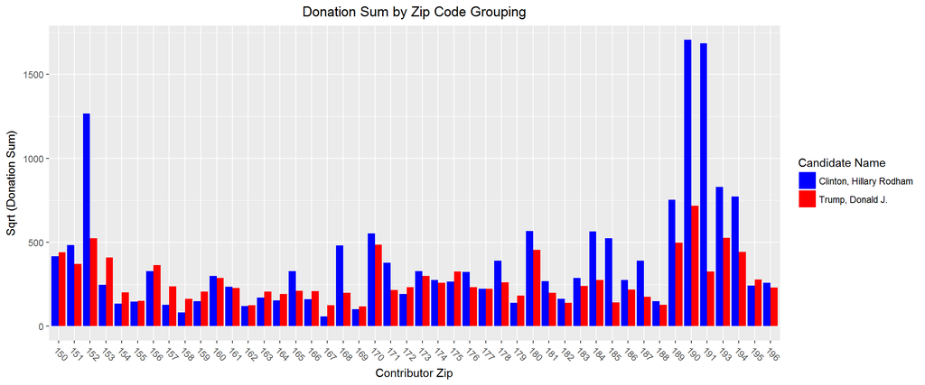

### Description Three

The above plot shows the total amount of money raised by general election candidates Hillary Clinton and Donald Trump throughout the entire 2016 Presidential Campaign in Pennsylvania. The x-axis shows Pennsylvania zip codes grouped by its first three digits. For example, all donations from contributors living in a zip code starting with “150” are summed up in the “150” column. The values were transformed using the square root function.

Democratic candidate Hillary Clinton raked in very large donation sums in the Pittsburgh and Philadelphia areas. Clinton raised over $1.5 million in Pittsburgh (152) and between $2.8 million and $3.0 million in Philadelphia (190,191). Clinton also outraised Trump by strong margins in the Philadelphia suburbs (189,193,194).

Donald Trump did better than Clinton in some traditionally Democratic areas of Pennsylvania. The zip code groupings of 153, 154, 157, 158, 159, and 167 - all in western Pennsylvania - gave Trump his best showing versus Clinton. The 153 and 154 areas - in the southwest corner of Pennsylvania - were solidly Democratic a generation ago. These donation hauls reveals in hindsight Donald Trump’s potental in Pennsylvania, considering that the residents have lower income than in the Philadelphia area. Trump also broke even with Clinton in Berks County (195 and 196) near Reading, Pennsylvania, another traditionally Democratic area.

Republican Donald Trump exceeded expectations and won Pennsylvania in the general election as he won over 60% of the vote in western Pennsylvania and also received more votes in Berks County than Hillary Clinton.

# Reflection

At the beginning of the analysis, I looked at the columns in the data set and determined their meanings from the “File Format” located on the Federal Election Commission [webpage](http://classic.fec.gov/disclosurep/PDownload.do). I very quickly decided not to focus on either individual donors nor employers since this report is being uploaded onto my public GitHub repository.

I noticed that some data cleaning needed to be done due to data errors. I performed some cleaning for city, zip code, and election type indicator. I renamed all of the columns so that the column name better reflected its meaning in the data set. In addition, I added a column for the candidate’s political party to simplify the analysis of donations by party.

I analyzed donation count, sums, and individual donations amounts. I expected to gain some insight from “amount per donations”. However, the Libertarians scored highest here - and John Kasich did best among Republicans! I had more luck looking at the contributor’s city, zip code, and occupation. Grouping zip codes helped me better understand the donors by geographic location.

When I was analyzing occupations, I noticed that “Attorneys” and “Lawyers” were both in Clinton donors’ top 10 occupations! I had to go back to the initial data set and combine occupations so that “Lawyers” could be paired with “Attorneys”. I combined several common occupations but there is more work to be done. For example, “Immigration Lawyer” and “Corporate Lawyer” could be combined into “Attorneys”. One could also attempt to analyze these different lawyer types separately but how to handle “Lawyer” and “Attorney”? Some occupation listings aren’t clear - should “CEO” and “Executive” be counted as the same occupation? “Information Requested” is the third most common occupation. I did not dive into this data since Hillary Clinton and Donald Trump had similar total donation sums from these donors.

The donation data set does not tell the story of the 2016 Presidential Election in Pennsylvania; it merely tells us about the donations made to the candidates. Different data sets are needed to determine how Donald Trump pulled off the victory. On the day after the election, USA Today published an [article](https://www.usatoday.com/story/news/politics/elections/2016/2016/11/09/another-way-trumps-bid-changed-politics/93565370/) claiming Trump only spent half as much money as Clinton nationwide. A data set with candidate spending data could provide a better picture.